# Don’t Get Kicked

#### Sample data of each column

```r
head(kcars)
```

|  | RefId | IsBadBuy | PurchDate | Auction | VehYear | VehicleAge | Make | Model | Trim | SubModel | Color | Transmission | WheelTypeID | WheelType | VehOdo | Nationality | Size | TopThreeAmericanName | MMRAcquisitionAuctionAveragePrice | MMRAcquisitionAuctionCleanPrice | MMRAcquisitionRetailAveragePrice | MMRAcquisitonRetailCleanPrice | MMRCurrentAuctionAveragePrice | MMRCurrentAuctionCleanPrice | MMRCurrentRetailAveragePrice | MMRCurrentRetailCleanPrice | PRIMEUNIT | AUCGUART | BYRNO | … |
| --- | --- | --- | --- | --- | --- | --- | --- | --- | --- | --- | --- | --- | --- | --- | --- | --- | --- | --- | --- | --- | --- | --- | --- | --- | --- | --- | --- | --- | --- | --- |
| 1 | 1 | 0 | 12/7/2009 | ADESA | 2006 | 3 | MAZDA | MAZDA3 | i | 4D SEDAN I | RED | AUTO | 1 | Alloy | 89046 | OTHER ASIAN | MEDIUM | OTHER | 8155 | 9829 | 11636 | 13600 | 7451 | 8552 | 11597 | 12409 | NULL | NULL | 21973 | … |
| 2 | 2 | 0 | 12/7/2009 | ADESA | 2004 | 5 | DODGE | 1500 RAM PICKUP 2WD | ST | QUAD CAB 4.7L SLT | WHITE | AUTO | 1 | Alloy | 93593 | AMERICAN | LARGE TRUCK | CHRYSLER | 6854 | 8383 | 10897 | 12572 | 7456 | 9222 | 11374 | 12791 | NULL | NULL | 19638 | … |
| 3 | 3 | 0 | 12/7/2009 | ADESA | 2005 | 4 | DODGE | STRATUS V6 | SXT | 4D SEDAN SXT FFV | MAROON | AUTO | 2 | Covers | 73807 | AMERICAN | MEDIUM | CHRYSLER | 3202 | 4760 | 6943 | 8457 | 4035 | 5557 | 7146 | 8702 | NULL | NULL | 19638 | … |
| 4 | 4 | 0 | 12/7/2009 | ADESA | 2004 | 5 | DODGE | NEON | SXT | 4D SEDAN | SILVER | AUTO | 1 | Alloy | 65617 | AMERICAN | COMPACT | CHRYSLER | 1893 | 2675 | 4658 | 5690 | 1844 | 2646 | 4375 | 5518 | NULL | NULL | 19638 | … |
| 5 | 5 | 0 | 12/7/2009 | ADESA | 2005 | 4 | FORD | FOCUS | ZX3 | 2D COUPE ZX3 | SILVER | MANUAL | 2 | Covers | 69367 | AMERICAN | COMPACT | FORD | 3913 | 5054 | 7723 | 8707 | 3247 | 4384 | 6739 | 7911 | NULL | NULL | 19638 | … |
| 6 | 6 | 0 | 12/7/2009 | ADESA | 2004 | 5 | MITSUBISHI | GALANT 4C | ES | 4D SEDAN ES | WHITE | AUTO | 2 | Covers | 81054 | OTHER ASIAN | MEDIUM | OTHER | 3901 | 4908 | 6706 | 8577 | 4709 | 5827 | 8149 | 9451 | NULL | NULL | 19638 | … |

#### Summary of each column of Cars data

```r
summary(kcars)
```

```
     RefId          IsBadBuy      PurchDate           Auction             VehYear
 Min.   :    1   Min.   :0.000   Length:72983       Length:72983       Min.   :2001
 1st Qu.:18258   1st Qu.:0.000   Class :character   Class :character   1st Qu.:2004
 Median :36514   Median :0.000   Mode  :character   Mode  :character   Median :2005
 Mean   :36511   Mean   :0.123                                         Mean   :2005
 3rd Qu.:54765   3rd Qu.:0.000                                         3rd Qu.:2007
 Max.   :73014   Max.   :1.000                                         Max.   :2010
   VehicleAge        Make              Model               Trim             SubModel
 Min.   :0.000   Length:72983       Length:72983       Length:72983       Length:72983
 1st Qu.:3.000   Class :character   Class :character   Class :character   Class :character
 Median :4.000   Mode  :character   Mode  :character   Mode  :character   Mode  :character
 Mean   :4.177
 3rd Qu.:5.000
 Max.   :9.000
    Color           Transmission       WheelTypeID         WheelType             VehOdo
 Length:72983       Length:72983       Length:72983       Length:72983       Min.   :  4825
 Class :character   Class :character   Class :character   Class :character   1st Qu.: 61837
 Mode  :character   Mode  :character   Mode  :character   Mode  :character   Median : 73361
                                                                             Mean   : 71500
                                                                             3rd Qu.: 82436
                                                                             Max.   :115717
 Nationality            Size           TopThreeAmericanName MMRAcquisitionAuctionAveragePrice
 Length:72983       Length:72983       Length:72983         Length:72983
 Class :character   Class :character   Class :character     Class :character
 Mode  :character   Mode  :character   Mode  :character     Mode  :character



 MMRAcquisitionAuctionCleanPrice MMRAcquisitionRetailAveragePrice MMRAcquisitonRetailCleanPrice
 Length:72983                    Length:72983                     Length:72983
 Class :character                Class :character                 Class :character
 Mode  :character                Mode  :character                 Mode  :character



 MMRCurrentAuctionAveragePrice MMRCurrentAuctionCleanPrice MMRCurrentRetailAveragePrice
 Length:72983                  Length:72983                Length:72983
 Class :character              Class :character            Class :character
 Mode  :character              Mode  :character            Mode  :character



 MMRCurrentRetailCleanPrice  PRIMEUNIT           AUCGUART             BYRNO
 Length:72983               Length:72983       Length:72983       Min.   :  835
 Class :character           Class :character   Class :character   1st Qu.:17212
 Mode  :character           Mode  :character   Mode  :character   Median :19662
                                                                  Mean   :26346
                                                                  3rd Qu.:22808
                                                                  Max.   :99761
     VNZIP1          VNST              VehBCost      IsOnlineSale      WarrantyCost
 Min.   : 2764   Length:72983       Min.   :    1   Min.   :0.00000   Min.   : 462
 1st Qu.:32124   Class :character   1st Qu.: 5435   1st Qu.:0.00000   1st Qu.: 837
 Median :73108   Mode  :character   Median : 6700   Median :0.00000   Median :1155
 Mean   :58043                      Mean   : 6731   Mean   :0.02528   Mean   :1277
 3rd Qu.:80022                      3rd Qu.: 7900   3rd Qu.:0.00000   3rd Qu.:1623
 Max.   :99224                      Max.   :45469   Max.   :1.00000   Max.   :7498
```

### Step-4 Data Cleansing

#### Remove data elements not useful for analysis

```r
# Since VehYear is available, Purchase Date is redundant and can be removed.
kcars$PurchDate <- NULL
# AUCGUART has 69,564 NULLs, and other 2 levels have very low numbers - 3357 and 62. so remove it.
kcars$AUCGUART <- NULL
# PRIMEUNITE also has more than 69K records with NULL values in it. This can also be removed.
kcars$PRIMEUNIT <- NULL
```

#### Set Transmission type either as Auto or Manual

```r
kcars$Transmission[grep("Manual", kcars$Transmission , ignore.case=FALSE, fixed=FALSE)] <- "MANUAL"
kcars$Transmission[grep("NULL", kcars$Transmission , ignore.case=TRUE, fixed=FALSE)] <- NA
kcars$Transmission <- factor(kcars$Transmission, levels=c("AUTO","MANUAL"))
```

#### Set Wheel Type ID and Wheel TYpe mapping appropriately

```r
#Wheel Type ID and Wheel Type are mapped:
# 0 ID -> NULL Type; 1 -> Alloy; 2 -> Covers; 3 -> Special
# NULL in wheelTypeID should be set to 0 to ensure it maps to all NULLs in wheelType
kcars$WheelTypeID[grep("NULL", kcars$WheelTypeID , ignore.case=TRUE, fixed=FALSE)] <- 0
kcars$WheelTypeID <- factor(kcars$WheelTypeID, levels=c(0,1,2,3))
#NULL wheelType appears to be Steel type
kcars$WheelType[grep("NULL", kcars$WheelType , ignore.case=FALSE, fixed=FALSE)] <- NA
kcars$WheelType <- as.factor(ifelse(is.na(kcars$WheelType), "Steel", kcars$WheelType))
#kcars$WheelType <- revalue(kcars$WheelType,
#                           c("1"="Alloy", "2"="Covers", "4" = "Special", "Steel" = "Steel"))
kcars$WheelType <- factor(kcars$WheelType, c("Alloy", "Covers", "Special", "Steel"))
```

#### Set TopThreeAmericanName NULL value to Other

```r
kcars$TopThreeAmericanName[grep("NULL", kcars$TopThreeAmericanName , ignore.case=TRUE, fixed=FALSE)] <- "OTHER"
kcars$TopThreeAmericanName <- factor(kcars$TopThreeAmericanName, levels=c("CHRYSLER","FORD", "GM", "OTHER"))
```

#### Fix Null values of Color and Size, and Numeric series of Trim Values

```r
kcars$Color[grep("NULL", kcars$Color , ignore.case=TRUE, fixed=FALSE)] <- NA
kcars$Size[grep("NULL", kcars$Size , ignore.case=TRUE, fixed=FALSE)] <- NA
kcars$Trim[grep("NULL", kcars$Trim , ignore.case=TRUE, fixed=FALSE)] <- NA
kcars$Trim[grep("^1", kcars$Trim , ignore.case=TRUE, fixed=FALSE)] <-"1XX"
kcars$Trim[grep("^2", kcars$Trim , ignore.case=TRUE, fixed=FALSE)] <-"2XX"
kcars$Trim[grep("^3", kcars$Trim , ignore.case=TRUE, fixed=FALSE)] <-"3XX"
```

#### Set approrpriate value for NULL Nationality as Other

```r
kcars$Nationality[grep("NULL", kcars$Nationality , ignore.case=TRUE, fixed=FALSE)] <- "OTHER"
kcars$Nationality <- factor(kcars$Nationality, levels=c("AMERICAN","OTHER", "OTHER ASIAN", "TOP LINE ASIAN"))
```

##### Set all other field values

```r
kcars$MMRCurrentAuctionAveragePrice[grep("NULL", kcars$MMRCurrentAuctionAveragePrice , ignore.case=TRUE, fixed=FALSE)] <- NA
kcars$MMRCurrentAuctionCleanPrice[grep("NULL", kcars$MMRCurrentAuctionCleanPrice , ignore.case=TRUE, fixed=FALSE)] <- NA
kcars$MMRCurrentRetailAveragePrice[grep("NULL", kcars$MMRCurrentRetailAveragePrice , ignore.case=TRUE, fixed=FALSE)] <- NA
kcars$MMRCurrentRetailCleanPrice[grep("NULL", kcars$MMRCurrentRetailCleanPrice , ignore.case=TRUE, fixed=FALSE)] <- NA
kcars$Cyl <- "V4"
kcars$Cyl[grep("V6", kcars$Model , ignore.case=TRUE, fixed=FALSE)] <- "V6"
kcars$Cyl[grep("V8", kcars$Model , ignore.case=TRUE, fixed=FALSE)] <- "V8"
kcars$PowerTrain <- "2WD"
kcars$PowerTrain[grep("4WD", kcars$Model , ignore.case=TRUE, fixed=FALSE)] <- "4WD"
kcars$PowerTrain[grep("FWD", kcars$Model , ignore.case=TRUE, fixed=FALSE)] <- "4WD"
kcars$PowerTrain[grep("AWD", kcars$Model , ignore.case=TRUE, fixed=FALSE)] <- "AWD"
kcars$Doors <- "4D"
kcars$Doors[grep("2D", kcars$SubModel , ignore.case=TRUE, fixed=FALSE)] <- "2D"
kcars$Doors[grep("3D", kcars$SubModel , ignore.case=TRUE, fixed=FALSE)] <- "3D"
kcars$Doors[grep("5D", kcars$SubModel , ignore.case=TRUE, fixed=FALSE)] <- "5D"
kcars$SubModelType <- "SEDAN"
kcars$SubModelType[grep("CAB", kcars$SubModel , ignore.case=TRUE, fixed=FALSE)] <- "CAB"
kcars$SubModelType[grep("CUV", kcars$SubModel , ignore.case=TRUE, fixed=FALSE)] <- "CUV"
kcars$SubModelType[grep("MINIVAN", kcars$SubModel , ignore.case=TRUE, fixed=FALSE)] <- "MINIVAN"
kcars$SubModelType[grep("UTILITY", kcars$SubModel , ignore.case=TRUE, fixed=FALSE)] <- "UTILITY"
kcars$SubModelType[grep("SPORT", kcars$SubModel , ignore.case=TRUE, fixed=FALSE)] <- "SPORT"
kcars$SubModelType[grep("PASSENGER", kcars$SubModel , ignore.case=TRUE, fixed=FALSE)] <- "PASSENGER"
kcars$SubModelType[grep("SUV", kcars$SubModel , ignore.case=TRUE, fixed=FALSE)] <- "SUV"
kcars$SubModelType[grep("WAGON", kcars$SubModel , ignore.case=TRUE, fixed=FALSE)] <- "WAGON"
kcars$SubModelType[grep("CONVERTIBLE", kcars$SubModel , ignore.case=TRUE, fixed=FALSE)] <- "CONVERTIBLE"
kcars$SubModelType[grep("HATCHBACK", kcars$SubModel , ignore.case=TRUE, fixed=FALSE)] <- "HATCHBACK"
kcars$SubModel <- NULL
kcars$Make[grep("TOYOTA SCION", kcars$Make , ignore.case=TRUE, fixed=FALSE)] <-"SCION"
kcars$Make[grep("HUMMER", kcars$Make , ignore.case=TRUE, fixed=FALSE)] <-"CADILLAC"
kcars$Make[grep("CADILLAC", kcars$Make , ignore.case=TRUE, fixed=FALSE)] <-"CADI-HUM"
kcars$Make[grep("PLYMOUTH", kcars$Make , ignore.case=TRUE, fixed=FALSE)] <-"CHRYSLER"
kcars$Model <- NULL
kcars$Auction <- as.factor(kcars$Auction)
kcars$Make <- as.factor(kcars$Make)
kcars$Trim <- as.factor(kcars$Trim)
kcars$Color <- as.factor(kcars$Color)
kcars$Size <- as.factor(kcars$Size)
kcars$Cyl <- as.factor(kcars$Cyl)
kcars$PowerTrain <- as.factor(kcars$PowerTrain)
kcars$Doors <- as.factor(kcars$Doors)
kcars$SubModelType <- as.factor(kcars$SubModelType)
kcars$VNST <- as.factor(kcars$VNST)
kcars$MMRAcquisitionAuctionAveragePrice <- as.integer(kcars$MMRAcquisitionAuctionAveragePrice)
```

```
NAs introduced by coercion
```

```r
kcars$MMRAcquisitionAuctionCleanPrice <- as.integer(kcars$MMRAcquisitionAuctionCleanPrice)
```

```
NAs introduced by coercion
```

```r
kcars$MMRAcquisitionRetailAveragePrice <- as.integer(kcars$MMRAcquisitionRetailAveragePrice)
```

```
NAs introduced by coercion
```

```r
kcars$MMRAcquisitonRetailCleanPrice <- as.integer(kcars$MMRAcquisitonRetailCleanPrice)
```

```
NAs introduced by coercion
```

```r
kcars$MMRCurrentAuctionAveragePrice <- as.integer(kcars$MMRCurrentAuctionAveragePrice)
kcars$MMRCurrentAuctionCleanPrice <- as.integer(kcars$MMRCurrentAuctionCleanPrice)
kcars$MMRCurrentRetailAveragePrice <- as.integer(kcars$MMRCurrentRetailAveragePrice)
kcars$MMRCurrentRetailCleanPrice <- as.integer(kcars$MMRCurrentRetailCleanPrice)
```

#### Run a quick summary of kcars

```r
summary(kcars)
```

```
     RefId          IsBadBuy        Auction         VehYear       VehicleAge
 Min.   :    1   Min.   :0.000   ADESA  :14439   Min.   :2001   Min.   :0.000
 1st Qu.:18258   1st Qu.:0.000   MANHEIM:41043   1st Qu.:2004   1st Qu.:3.000
 Median :36514   Median :0.000   OTHER  :17501   Median :2005   Median :4.000
 Mean   :36511   Mean   :0.123                   Mean   :2005   Mean   :4.177
 3rd Qu.:54765   3rd Qu.:0.000                   3rd Qu.:2007   3rd Qu.:5.000
 Max.   :73014   Max.   :1.000                   Max.   :2010   Max.   :9.000

        Make            Trim           Color       Transmission   WheelTypeID   WheelType
 CHEVROLET:17248   Bas    :13950   SILVER :14875   AUTO  :70398   0: 3174     Alloy  :36050
 DODGE    :12912   LS     :10174   WHITE  :12123   MANUAL: 2576   1:36050     Covers :33004
 FORD     :11305   SE     : 9348   BLUE   :10347   NA's  :    9   2:33004     Special:  755
 CHRYSLER : 8846   SXT    : 3825   GREY   : 7887                  3:  755     Steel  : 3174
 PONTIAC  : 4258   LT     : 3540   BLACK  : 7627
 KIA      : 2484   LX     : 2417   (Other):20116
 (Other)  :15930   (Other):29729   NA's   :    8
     VehOdo               Nationality            Size       TopThreeAmericanName
 Min.   :  4825   AMERICAN      :61028   MEDIUM    :30785   CHRYSLER:23399
 1st Qu.: 61837   OTHER         :  200   LARGE     : 8850   FORD    :12315
 Median : 73361   OTHER ASIAN   : 8033   MEDIUM SUV: 8090   GM      :25314
 Mean   : 71500   TOP LINE ASIAN: 3722   COMPACT   : 7205   OTHER   :11955
 3rd Qu.: 82436                          VAN       : 5854
 Max.   :115717                          (Other)   :12194
                                         NA's      :    5
 MMRAcquisitionAuctionAveragePrice MMRAcquisitionAuctionCleanPrice
 Min.   :    0                     Min.   :    0
 1st Qu.: 4273                     1st Qu.: 5406
 Median : 6097                     Median : 7303
 Mean   : 6129                     Mean   : 7374
 3rd Qu.: 7765                     3rd Qu.: 9021
 Max.   :35722                     Max.   :36859
 NA's   :18                        NA's   :18
 MMRAcquisitionRetailAveragePrice MMRAcquisitonRetailCleanPrice MMRCurrentAuctionAveragePrice
 Min.   :    0                    Min.   :    0                 Min.   :    0
 1st Qu.: 6280                    1st Qu.: 7493                 1st Qu.: 4275
 Median : 8444                    Median : 9789                 Median : 6062
 Mean   : 8497                    Mean   : 9851                 Mean   : 6132
 3rd Qu.:10651                    3rd Qu.:12088                 3rd Qu.: 7736
 Max.   :39080                    Max.   :41482                 Max.   :35722
 NA's   :18                       NA's   :18                    NA's   :315
```

[output cut: 9 more lines]

```
 Min.   :  835   Min.   : 2764   TX     :13596   Min.   :    1   Min.   :0.00000
 1st Qu.:17212   1st Qu.:32124   FL     :10447   1st Qu.: 5435   1st Qu.:0.00000
 Median :19662   Median :73108   CA     : 7095   Median : 6700   Median :0.00000
 Mean   :26346   Mean   :58043   NC     : 7042   Mean   : 6731   Mean   :0.02528
 3rd Qu.:22808   3rd Qu.:80022   AZ     : 6174   3rd Qu.: 7900   3rd Qu.:0.00000
 Max.   :99761   Max.   :99224   CO     : 4998   Max.   :45469   Max.   :1.00000
                                 (Other):23631
  WarrantyCost  Cyl        PowerTrain  Doors       SubModelType
 Min.   : 462   V4:44255   2WD:61606   2D: 3354   SEDAN  :45018
 1st Qu.: 837   V6:25075   4WD:10626   3D:   51   SUV    : 8514
 Median :1155   V8: 3653   AWD:  751   4D:69491   WAGON  : 4162
 Mean   :1277                          5D:   87   CAB    : 3869
 3rd Qu.:1623                                     MINIVAN: 3083
 Max.   :7498                                     SPORT  : 3020
                                                  (Other): 5317
```

### Step-5 Feature Engineering

#### Use only a subset of fields

```r
# VNST, Trim, WheelType, Make, NewModel left out
# Transmission, Cyl, Doors, WarrantyCost, MMRAcquisitionAuctionAveragePrice,
# MMRAcquisitionAuctionCleanPrice, MMRAcquisitonRetailCleanPrice,
# MMRCurrentAuctionAveragePrice, MMRCurrentRetailAveragePrice
# found not significant in the model
useColumns <- c("IsBadBuy","Auction","VehYear","VehicleAge","Color",
                "WheelTypeID","VehOdo","Nationality","Size",
                "BYRNO","VNZIP1","VehBCost","IsOnlineSale",
                "MMRAcquisitionRetailAveragePrice",
                "MMRCurrentAuctionCleanPrice",
                "MMRCurrentRetailCleanPrice",
                "PowerTrain","SubModelType")
```

#### Use One-Hot Encoding technique for categorical variables

```r
dmy <- dummyVars(" ~ .", data = kcars[,(useColumns)])
kcarsTrans <- data.frame(predict(dmy, newdata = kcars[,(useColumns)]))
str(kcarsTrans)
```

```
'data.frame':   72983 obs. of  64 variables:
 $ IsBadBuy                        : num  0 0 0 0 0 0 0 0 0 0 ...
 $ Auction.ADESA                   : num  1 1 1 1 1 1 1 1 1 1 ...
 $ Auction.MANHEIM                 : num  0 0 0 0 0 0 0 0 0 0 ...
 $ Auction.OTHER                   : num  0 0 0 0 0 0 0 0 0 0 ...
 $ VehYear                         : num  2006 2004 2005 2004 2005 ...
 $ VehicleAge                      : num  3 5 4 5 4 5 5 4 2 2 ...
 $ Color.BEIGE                     : num  0 0 0 0 0 0 0 0 0 0 ...
 $ Color.BLACK                     : num  0 0 0 0 0 0 1 0 1 0 ...
 $ Color.BLUE                      : num  0 0 0 0 0 0 0 0 0 0 ...
 $ Color.BROWN                     : num  0 0 0 0 0 0 0 0 0 0 ...
 $ Color.GOLD                      : num  0 0 0 0 0 0 0 0 0 0 ...
 $ Color.GREEN                     : num  0 0 0 0 0 0 0 0 0 0 ...
 $ Color.GREY                      : num  0 0 0 0 0 0 0 0 0 0 ...
 $ Color.MAROON                    : num  0 0 1 0 0 0 0 0 0 0 ...
```

[output cut: 50 more lines]

### Step-6 Data Visualization

#### List the fields in the order of their correlation

```r
corList <- flattenSquareMatrix(cor.prob(kcarsTrans))
corOrdList <- corList[order(-abs(corList$cor)),]
head(corOrdList)
```

|  | i | j | cor | p |
| --- | --- | --- | --- | --- |
| 1326 | PowerTrain.2WD | PowerTrain.4WD | -0.9605941 | 0 |
| 15 | VehYear | VehicleAge | -0.9579571 | 0 |
| 1225 | MMRCurrentAuctionCleanPrice | MMRCurrentRetailCleanPrice | 0.9215365 | 0 |
| 1224 | MMRAcquisitionRetailAveragePrice | MMRCurrentRetailCleanPrice | 0.9060544 | 0 |
| 300 | WheelTypeID.1 | WheelTypeID.2 | -0.8976616 | 0 |
| 1414 | Size.LARGE.TRUCK | SubModelType.CAB | 0.8571248 | 0 |

#### Only list the fields that are correlated to IsBadBuy by more than 4%

```r
corOrdList[corOrdList$j=='IsBadBuy',]
```

| i | j | cor | p |
| --- | --- | --- | --- |

```r
selectedSub <- subset(corOrdList, (abs(cor)>0.04 & corOrdList$i == 'IsBadBuy'))
selectedSub
```

|  | i | j | cor | p |
| --- | --- | --- | --- | --- |
| 232 | IsBadBuy | WheelTypeID.0 | 0.37773658 | 0 |
| 11 | IsBadBuy | VehicleAge | 0.16716408 | 0 |
| 7 | IsBadBuy | VehYear | -0.15888630 | 0 |
| 277 | IsBadBuy | WheelTypeID.2 | -0.11769539 | 0 |
| 1129 | IsBadBuy | MMRCurrentAuctionCleanPrice | -0.10402018 | 0 |
| 1177 | IsBadBuy | MMRCurrentRetailCleanPrice | -0.10024528 | 0 |
| 991 | IsBadBuy | VehBCost | -0.09991146 | 0 |
| 1082 | IsBadBuy | MMRAcquisitionRetailAveragePrice | -0.08741840 | 0 |
| 326 | IsBadBuy | VehOdo | 0.08256043 | 0 |
| 904 | IsBadBuy | BYRNO | -0.06148841 | 0 |

[output cut: 1 more lines]

Plots, Aggregation, and Correlation Chart were used to get more insight on the data. An example of a correlation plot is given below.

#### Correlation Chart

```r
bestSub <- as.character(selectedSub$j[c(1,2,3,5,6,7)])
bestSub
```

```
[1] "WheelTypeID.0"               "VehicleAge"                  "VehYear"
[4] "MMRCurrentAuctionCleanPrice" "MMRCurrentRetailCleanPrice"  "VehBCost"
```

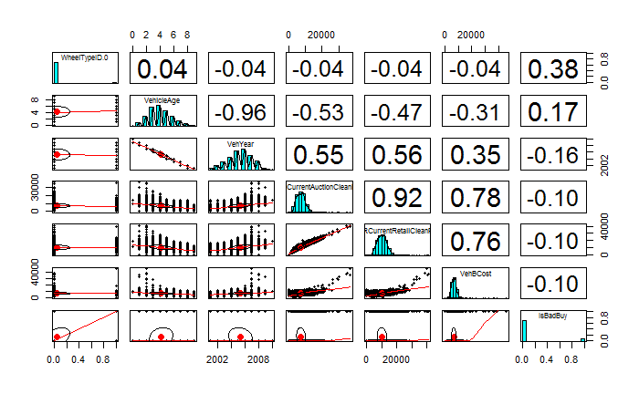

```r
pairs.panels(kcarsTrans[c(bestSub,'IsBadBuy')])
```

#### Plots of Vehicle Age and Vehicle Year:

Red lines indicate total number of vehicles per vehicle age, and the following blue line indicate that IsBadBuy = 0 indicating that they are marked as good. These charts display both the range of data, and the distribution of the response classes.

```r
par(mfrow=c(2,1))
total <- ddply(kcars, c("VehicleAge"), summarise, N= length(RefId))
isGood <- ddply(kcars, c("VehicleAge"), summarise, N= sum(!IsBadBuy))
plot(total, type="l", col="red", xlab="Vehicle Age", ylab="Total", cex.lab=0.8, lwd=2,  xlim=c(0, 10), ylim=c(0, 20000))
par(new = T)
```

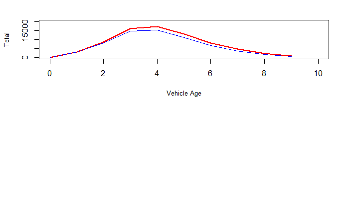

```r
plot(isGood, type="l", col="blue", xlab='', ylab='', xlim=c(0, 10), (ylim=c(0, 20000)), axes=F)
```

```r
total <- ddply(kcars, c("VehYear"), summarise, N= length(RefId))
isGood <- ddply(kcars, c("VehYear"), summarise, N= sum(!IsBadBuy))
plot(total, type="l", col="red", xlab="Vehicle Year", ylab="Total", cex.lab=0.8, lwd=2,  xlim=c(2000, 2012), ylim=c(0, 20000))
par(new = T)
```

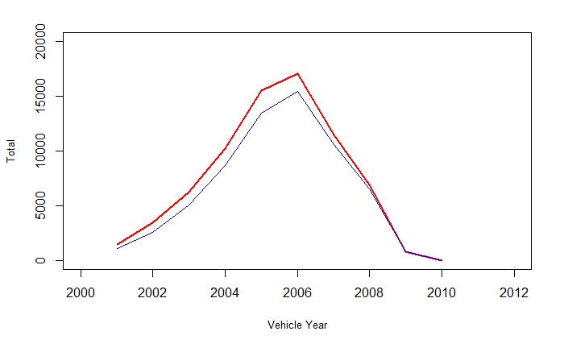

```r
plot(isGood, type="l", col="blue", xlab='', ylab='', xlim=c(2000, 2012), (ylim=c(0, 20000)), axes=F)
```

```r
total <- ddply(kcars, c("Size"), summarise, N= length(RefId))
isGood <- ddply(kcars, c("Size"), summarise, N= sum(!IsBadBuy))
total$Size <- factor(total$Size, labels=c(1,2,3,4,5,6,7,8,9,10,11,12))
plot(total, type="l", col="red", xlab="Size", ylab="Total", xlim=c(1, 14), ylim=c(1, 32000))
par(new = T)
```

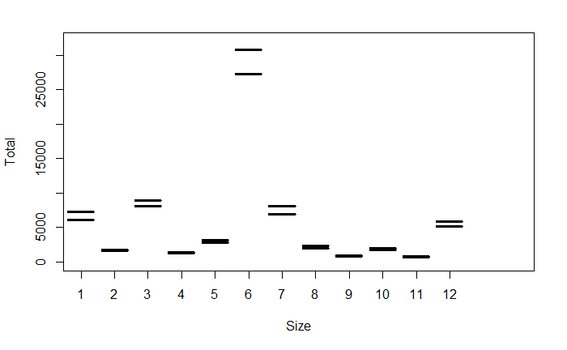

```r
plot(isGood, type="l", col="blue", xlab='', ylab='', xlim=c(1, 14), ylim=c(1, 32000), axes=F)
```

```r
total <- ddply(kcars, c("IsOnlineSale"), summarise, N= length(RefId))
isGood <- ddply(kcars, c("IsOnlineSale"), summarise, N= sum(!IsBadBuy))
plot(total, type="l", col="red", xlab="Online Sale", ylab="Total", cex.lab=0.8, lwd=2,  xlim=c(0, 1), ylim=c(1000, 75000))
par(new = T)
```

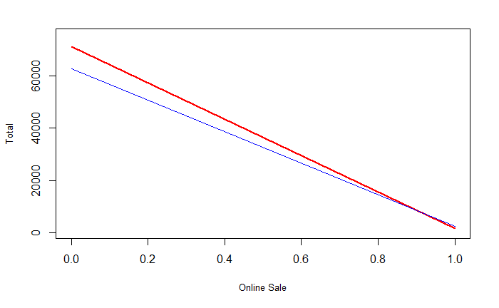

```r
plot(isGood, type="l", col="blue", xlab='', ylab='', xlim=c(0, 1), (ylim=c(1, 75000)), axes=F)
```

#### Tabular Results

```r
xtabs(~IsBadBuy + Size, data = kcars[complete.cases(kcars),(useColumns)])
```

```
        Size
IsBadBuy COMPACT CROSSOVER LARGE LARGE SUV LARGE TRUCK MEDIUM MEDIUM SUV SMALL SUV SMALL TRUCK
       0    6041      1575  8011      1196        2797  27064       6876      1955         735
       1    1144       182   815       232         359   3524       1191       312         125
        Size
IsBadBuy SPECIALTY SPORTS   VAN
       0      1737    633  5095
       1       176    144   739
```

```r
xtabs(~IsBadBuy + Color, data = kcars[complete.cases(kcars),(useColumns)])
```

```
        Color
IsBadBuy BEIGE BLACK  BLUE BROWN  GOLD GREEN  GREY MAROON NOT AVAIL ORANGE OTHER PURPLE   RED
       0  1365  6743  9116   379  4465  2773  6944   1785        65    381   212    316  5411
       1   209   856  1182    55   736   401   909    259        24     34    29     55   824
        Color
IsBadBuy SILVER WHITE YELLOW
       0  12967 10583    210
       1   1834  1502     34
```

```r
xtabs(~IsBadBuy + PowerTrain, data = kcars[complete.cases(kcars),(useColumns)])
```

```
        PowerTrain
IsBadBuy   2WD   4WD   AWD
       0 53950  9157   608
       1  7369  1432   142
```

```r
xtabs(~IsBadBuy + SubModelType, data = kcars[complete.cases(kcars),(useColumns)])
```

```
        SubModelType
IsBadBuy   CAB CONVERTIBLE   CUV HATCHBACK MINIVAN PASSENGER SEDAN SPORT   SUV UTILITY WAGON
       0  3390         381  1500       196    2700      1998 39467  2559  7333     532  3659
       1   462          79   213        30     369       291  5318   456  1149      79   497
```

```r
xtabs(~IsBadBuy + Nationality, data = kcars[complete.cases(kcars),(useColumns)])
```

```
        Nationality
IsBadBuy AMERICAN OTHER OTHER ASIAN TOP LINE ASIAN
       0    53379   168        6957           3211
       1     7354    27        1061            501
```

### Step-7 Modeling

#### Split into Training/Test Data Sets

```
[1] 325
   msk
Y   FALSE  TRUE
  0 32003 32004
  1  4488  4488
[1] "Label 0 numbers: total= 64007 , train= 32004 , test1= 32003 , ratio= 0.500007811645601"
[1] "Label 1 numbers: total= 8976 , train= 4488 , test1= 4488 , ratio= 0.5"
   msk
Y   FALSE  TRUE
  0 16001 16002
  1  2244  2244
[1] "All Labels numbers: total= 36491 , test1= 18246 , test2= 18245 , ratio= 0.500013702008714"
[1] "Label 0 numbers: total= 32003 , test1= 16002 , test2= 16001 , ratio= 0.500015623535294"
[1] "Label 1 numbers: total= 4488 , test1= 2244 , test2= 2244 , ratio= 0.5"
```

```r
# use results
test_1 <- test[ msk,]  # use output of sample.split to ...
test_2 <- test[!msk,]

test <- NULL
str(train[complete.cases(train),(useColumns)])
```

```
'data.frame':   36334 obs. of  18 variables:
 $ IsBadBuy                        : int  0 0 0 0 0 0 0 0 0 0 ...
 $ Auction                         : Factor w/ 3 levels "ADESA","MANHEIM",..: 1 1 1 1 1 1 1 1 1 1 ...
 $ VehYear                         : int  2006 2005 2004 2007 2001 2003 2003 2005 2004 2003 ...
 $ VehicleAge                      : int  3 4 5 2 8 6 6 4 5 6 ...
 $ Color                           : Factor w/ 16 levels "BEIGE","BLACK",..: 13 8 15 13 15 15 13 7 2 5 ...
 $ WheelTypeID                     : Factor w/ 4 levels "0","1","2","3": 2 3 3 2 2 3 3 3 2 2 ...
 $ VehOdo                          : int  89046 73807 81054 84872 75419 72132 75156 65925 84498 77694 ...
 $ Nationality                     : Factor w/ 4 levels "AMERICAN","OTHER",..: 3 1 3 1 1 1 1 1 1 1 ...
 $ Size                            : Factor w/ 12 levels "COMPACT","CROSSOVER",..: 6 6 6 3 5 1 7 3 7 4 ...
 $ BYRNO                           : int  21973 19638 19638 21973 5546 5546 5546 19638 19638 19638 ...
 $ VNZIP1                          : int  33619 33619 33619 33619 33619 33619 33619 33619 33619 33619 ...
 $ VehBCost                        : num  7100 4900 5600 7700 5300 3300 4900 5700 7100 8300 ...
 $ IsOnlineSale                    : int  0 0 0 0 0 0 0 0 0 0 ...
 $ MMRAcquisitionRetailAveragePrice: int  11636 6943 6706 11734 5826 5256 5835 7316 11092 11181 ...
 $ MMRCurrentAuctionCleanPrice     : int  8552 5557 5827 10988 3822 2690 4572 5191 8766 8441 ...
 $ MMRCurrentRetailCleanPrice      : int  12409 8702 9451 14845 6559 5506 9364 8800 12609 12152 ...
 $ PowerTrain                      : Factor w/ 3 levels "2WD","4WD","AWD": 1 1 1 1 1 1 1 1 1 1 ...
 $ SubModelType                    : Factor w/ 11 levels "CAB","CONVERTIBLE",..: 7 7 7 7 1 7 3 7 10 10 ...
```

#### Build Logistic Regression Model and Print Summary

```r
gg <- glm(formula = IsBadBuy ~ ., data = train[complete.cases(train),(useColumns)],
          family=binomial(logit))
summary(gg)
```

```
Call:
glm(formula = IsBadBuy ~ ., family = binomial(logit), data = train[complete.cases(train),
    (useColumns)])

Deviance Residuals:
    Min       1Q   Median       3Q      Max
-2.2135  -0.4913  -0.3877  -0.2862   3.4826

Coefficients:
                                   Estimate Std. Error z value Pr(>|z|)
(Intercept)                      -8.366e+02  1.380e+02  -6.062 1.34e-09 ***
AuctionMANHEIM                    3.137e-02  4.570e-02   0.686 0.492444
AuctionOTHER                     -7.479e-02  5.579e-02  -1.341 0.180051
VehYear                           4.167e-01  6.872e-02   6.063 1.33e-09 ***
VehicleAge                        6.526e-01  6.396e-02  10.204  < 2e-16 ***
ColorBLACK                        6.907e-02  1.335e-01   0.517 0.604846
ColorBLUE                        -2.021e-02  1.300e-01  -0.155 0.876469
ColorBROWN                        2.386e-01  2.562e-01   0.931 0.351610
ColorGOLD                         1.029e-01  1.353e-01   0.761 0.446717
ColorGREEN                       -4.922e-02  1.462e-01  -0.337 0.736431
ColorGREY                         3.348e-02  1.324e-01   0.253 0.800325
ColorMAROON                       7.080e-02  1.580e-01   0.448 0.654055
ColorNOT AVAIL                   -1.997e-01  4.659e-01  -0.429 0.668213
ColorORANGE                       1.109e-01  2.884e-01   0.385 0.700526
ColorOTHER                       -1.177e+00  3.529e-01  -3.334 0.000856 ***
ColorPURPLE                       2.065e-01  2.512e-01   0.822 0.411075
ColorRED                          1.401e-01  1.343e-01   1.043 0.296918
ColorSILVER                       7.669e-02  1.266e-01   0.606 0.544565
ColorWHITE                        7.551e-02  1.279e-01   0.590 0.554994
ColorYELLOW                      -5.853e-01  3.465e-01  -1.689 0.091204 .
WheelTypeID1                     -3.231e+00  6.759e-02 -47.808  < 2e-16 ***
WheelTypeID2                     -3.400e+00  6.889e-02 -49.360  < 2e-16 ***
WheelTypeID3                     -3.105e+00  1.714e-01 -18.115  < 2e-16 ***
VehOdo                            3.699e-06  1.451e-06   2.549 0.010801 *
NationalityOTHER                  2.893e-01  3.211e-01   0.901 0.367625
NationalityOTHER ASIAN            4.712e-02  6.081e-02   0.775 0.438460
NationalityTOP LINE ASIAN         2.941e-01  8.861e-02   3.318 0.000906 ***
SizeCROSSOVER                     1.987e-03  2.050e-01   0.010 0.992266
SizeLARGE                        -1.336e-01  8.708e-02  -1.534 0.124967
SizeLARGE SUV                     5.224e-01  2.009e-01   2.601 0.009306 **
```

[output cut: 22 more lines]

```
SubModelTypeSEDAN                 2.117e-01  3.840e-01   0.551 0.581399
SubModelTypeSPORT                 1.489e-01  3.695e-01   0.403 0.686947
SubModelTypeSUV                   1.348e-01  3.629e-01   0.371 0.710322
SubModelTypeUTILITY               8.916e-02  4.072e-01   0.219 0.826679
SubModelTypeWAGON                 5.474e-01  3.802e-01   1.440 0.149931
---
Signif. codes:  0 *** 0.001 ** 0.01 * 0.05 . 0.1   1

(Dispersion parameter for binomial family taken to be 1)

    Null deviance: 27095  on 36333  degrees of freedom
Residual deviance: 22538  on 36277  degrees of freedom
AIC: 22652

Number of Fisher Scoring iterations: 5
```

#### Run ANOVA Analysis on the Model

```r
anova(gg)
```

```
Analysis of Deviance Table

Model: binomial, link: logit

Response: IsBadBuy

Terms added sequentially (first to last)

                                 Df Deviance Resid. Df Resid. Dev
NULL                                             36333      27095
Auction                           2    69.29     36331      27025
VehYear                           1   941.45     36330      26084
VehicleAge                        1   108.01     36329      25976
Color                            15    20.79     36314      25955
WheelTypeID                       3  3014.85     36311      22940
VehOdo                            1    29.28     36310      22911
Nationality                       3     5.76     36307      22905
Size                             11    60.36     36296      22845
BYRNO                             1    29.75     36295      22815
VNZIP1                            1    25.92     36294      22789
VehBCost                          1    88.81     36293      22700
IsOnlineSale                      1    22.56     36292      22678
MMRAcquisitionRetailAveragePrice  1    17.36     36291      22661
MMRCurrentAuctionCleanPrice       1     3.35     36290      22657
MMRCurrentRetailCleanPrice        1    67.28     36289      22590
PowerTrain                        2    25.40     36287      22565
SubModelType                     10    26.89     36277      22538
```

#### Confidence Interval, Degrees of Freedom, and p-value

```r
# Confidence Interval
# To find the difference in deviance between the current and null model (i.e., the test statistic)
with(gg, null.deviance - deviance)
```

```
[1] 4557.105
```

```r
#  The degrees of freedom for the difference between the two models is equal to the
#  number of predictor variables in the mode, and can be obtained using ...
with(gg, df.null - df.residual)
```

```
[1] 56
```

```r
#Finally, the p-value can be obtained using: ~0
with(gg, pchisq(null.deviance - deviance, df.null - df.residual, lower.tail = FALSE))
```

```
[1] 0
```

```r
#1 - pchisq(27095-22538,36333-36277)
# The chi-square of 4557.105 with 56 degrees of freedom and an associated
# p-value of less than 0.001 (0) tells us that our model as a whole fits
# significantly better than an empty model.
```

#### Drop single term from the model; result to include a test statistic also

```r
drop1(gg, test = "Chisq")
```

```
Single term deletions

Model:
IsBadBuy ~ Auction + VehYear + VehicleAge + Color + WheelTypeID +
    VehOdo + Nationality + Size + BYRNO + VNZIP1 + VehBCost +
    IsOnlineSale + MMRAcquisitionRetailAveragePrice + MMRCurrentAuctionCleanPrice +
    MMRCurrentRetailCleanPrice + PowerTrain + SubModelType
                                 Df Deviance   AIC     LRT  Pr(>Chi)
<none>                                 22538 22652
Auction                           2    22543 22653    5.13 0.0767325 .
VehYear                           1    22575 22687   36.98 1.194e-09 ***
VehicleAge                        1    22644 22756  106.59 < 2.2e-16 ***
Color                            15    22567 22651   29.23 0.0150303 *
WheelTypeID                       3    25535 25643 2997.46 < 2.2e-16 ***
VehOdo                            1    22544 22656    6.53 0.0106037 *
Nationality                       3    22549 22657   11.31 0.0101528 *
Size                             11    22560 22652   22.32 0.0219908 *
BYRNO                             1    22583 22695   45.13 1.846e-11 ***
VNZIP1                            1    22558 22670   20.52 5.901e-06 ***
VehBCost                          1    22637 22749   99.28 < 2.2e-16 ***
IsOnlineSale                      1    22557 22669   19.14 1.214e-05 ***
MMRAcquisitionRetailAveragePrice  1    22550 22662   11.89 0.0005645 ***
MMRCurrentAuctionCleanPrice       1    22581 22693   43.51 4.223e-11 ***
MMRCurrentRetailCleanPrice        1    22604 22716   66.09 4.308e-16 ***
PowerTrain                        2    22567 22677   29.87 3.262e-07 ***
SubModelType                     10    22565 22659   26.89 0.0027110 **
---
Signif. codes:  0 *** 0.001 ** 0.01 * 0.05 . 0.1   1
```